# R/RStudio (Part 1). Data wrangling, visualization & statistial analysis (CSB chap 9 + iris)

### 9.6.7 Plotting Experimental Errors

The standard deviation (SD) represents the dispersion of the data,4 the standard error of the mean (SEM) and confidence intervals (CI) report the certainty of the estimate of a value (e.g.,certainty in estimating the mean).

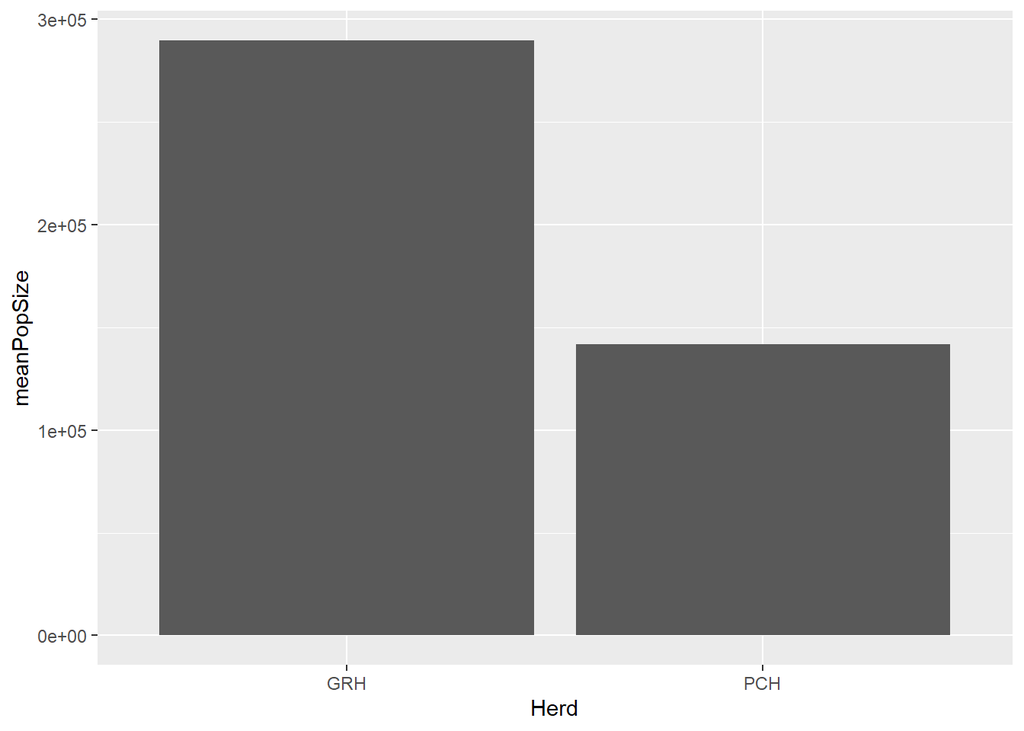

```r
#calculate summary stats and errors for herds GRH and PCH
stats <- popsize %>%
  filter(Herd %in% c("GRH", "PCH")) %>%
  group_by(Herd) %>%
  summarise(meanPopSize= mean(Pop_Size), SD = sd(Pop_Size), N = n(), SEM = SD/sqrt(N), CI = SEM * qt(0.975, N-1))

# plot mean population size as bar plot
ggplot(data = stats) +
  aes(x = Herd, y = meanPopSize) +
  geom_col()
```

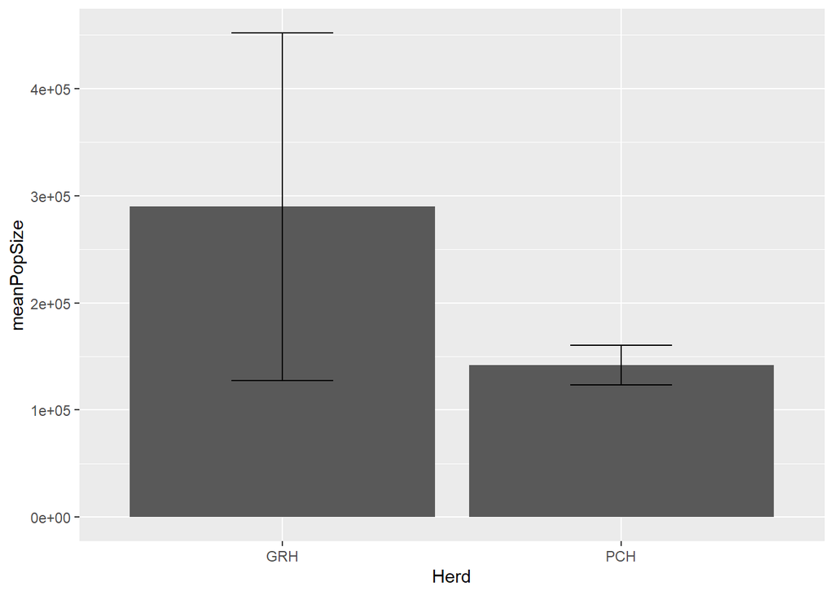

```r
# set up aesthetic mapping for confidence intervals
limits <- aes(ymax = stats$meanPopSize + stats$CI, ymin = stats$meanPopSize - stats$CI)
# plot including confidence intervals
ggplot(data = stats) +
  aes(x = Herd, y = meanPopSize) + geom_col() +
  geom_errorbar(limits, width = .3)
```

### Intermezzo 9.5

1. Explore the data set snow and plot the Perc_snowcover versus Week_snowmelt. Choose an appropriate geom.
2. For each year, compute the average Perc_snowcover and Week_snowmelt and create a scatter plot.
3. Produce a box plot of the Pop_Size for each Herd.
4. Create a scatter plot showing the average population size (taken across herds) including standard deviation, for the years 2008 through 2014.

### 9.6.8 Scales

Scales are used to modify the x- and y-axes, as well as to determine how colors, sizes, and shapes behave. You can set a scale for each aesthetic mapping. Here are a few other aesthetic mappings that you can modify using the corresponding scales:

```r
pl <- ggplot(data = popsize, aes(x = Herd, y = Pop_Size, fill = Herd)) +
  geom_boxplot()

show(pl)
```

[output not shown]

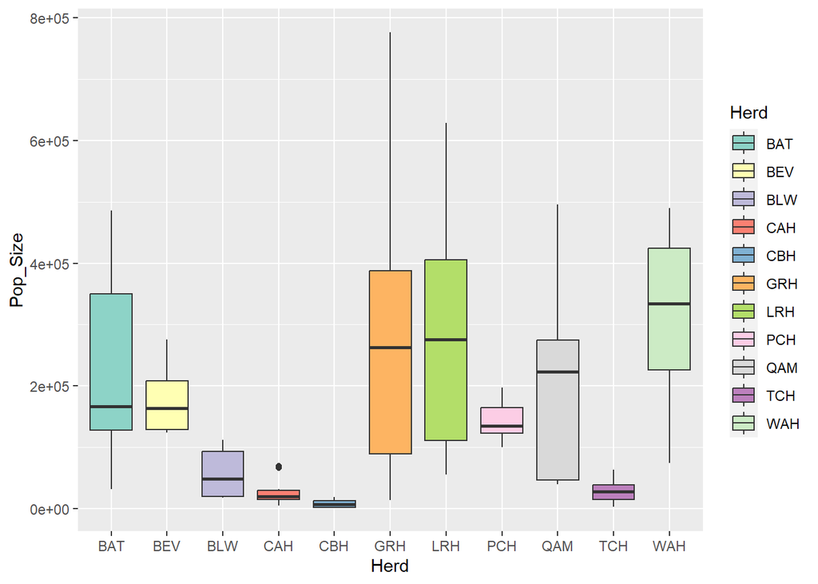

```r
# choose a palette from ColorBrewer
pl + scale_fill_brewer(palette = "Set3")
```

```r
# palette based on hue
pl + scale_fill_hue()
```

[output not shown]

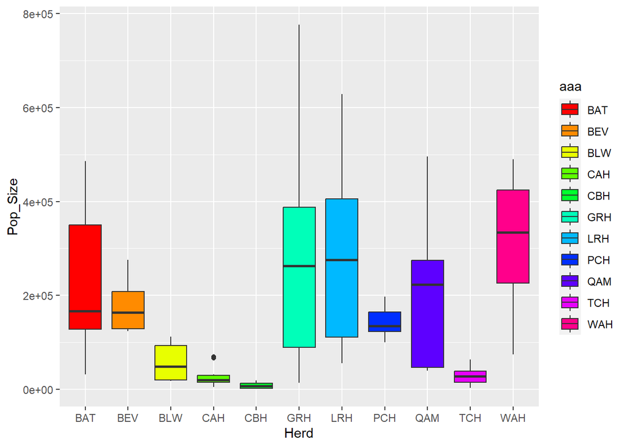

```r
# manually set values and rename the legend
pl + scale_fill_manual(values = rainbow(11), name = "aaa")
```

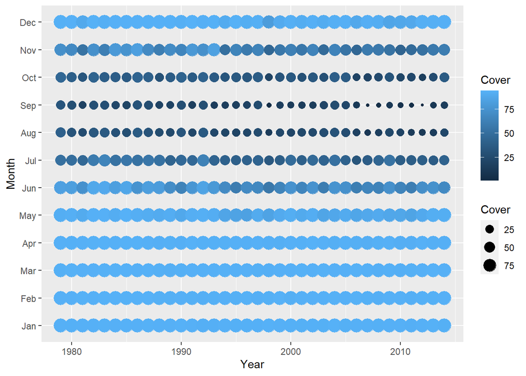

```r
#Similarly, you can set other scales such as size or colour. Take the graph
pl <- ggplot(data = seaice %>% filter(Herd == "BEV")) +
  aes(x = Year, y = Month, colour = Cover, size = Cover) +
  geom_point()
show(pl)
```

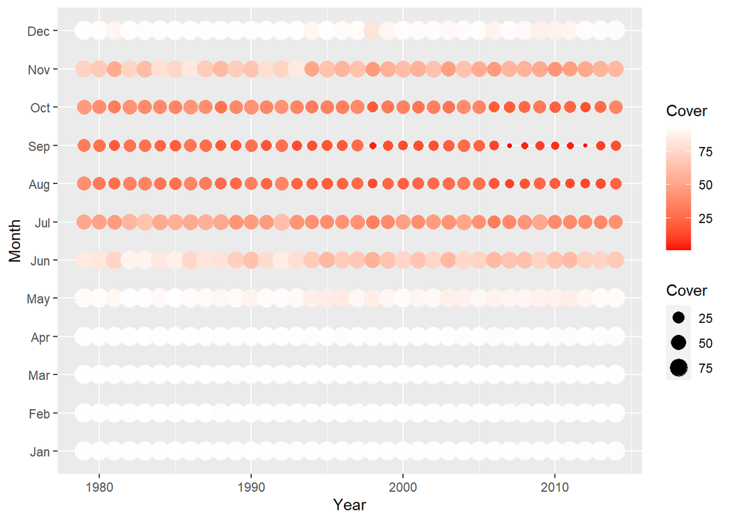

```r
pl +
  scale_colour_gradient(high = "white", low = "red")
```

### 9.6.9 Faceting

Sometimes you want to split data according to one or more variables, but still plot the resulting panels in one plot for easy comparison. In ggplot2 this operation is called faceting. Two functions are available to facet data: facet_wrap and facet_grid. While facet_wrap arranges panels sequentially and omits empty panels when a certain combination of variables is not available, facet_grid arranges all variable combinations in a grid regardless of data availability.

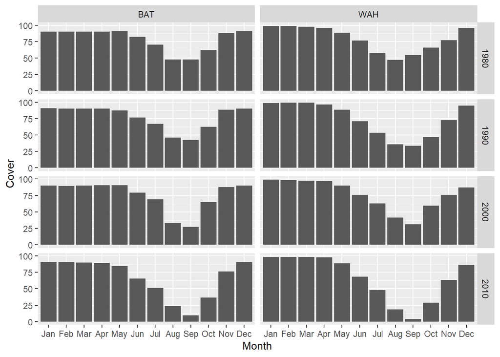

```r
seaice %>%
  filter(Herd %in% c("WAH", "BAT")) %>%
  filter(Year %in% c(1980, 1990, 2000, 2010)) %>%
  ggplot(aes(x = Month, y = Cover)) +
  geom_col() +
  facet_grid(Year~Herd)
```

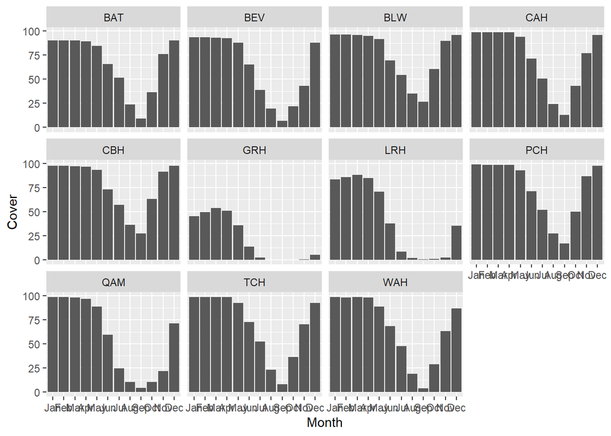

```r
ggplot(data = seaice %>% filter(Year == 2010)) +
  aes(x = Month, y = Cover) +
  geom_col() +
  facet_wrap(~Herd)
```

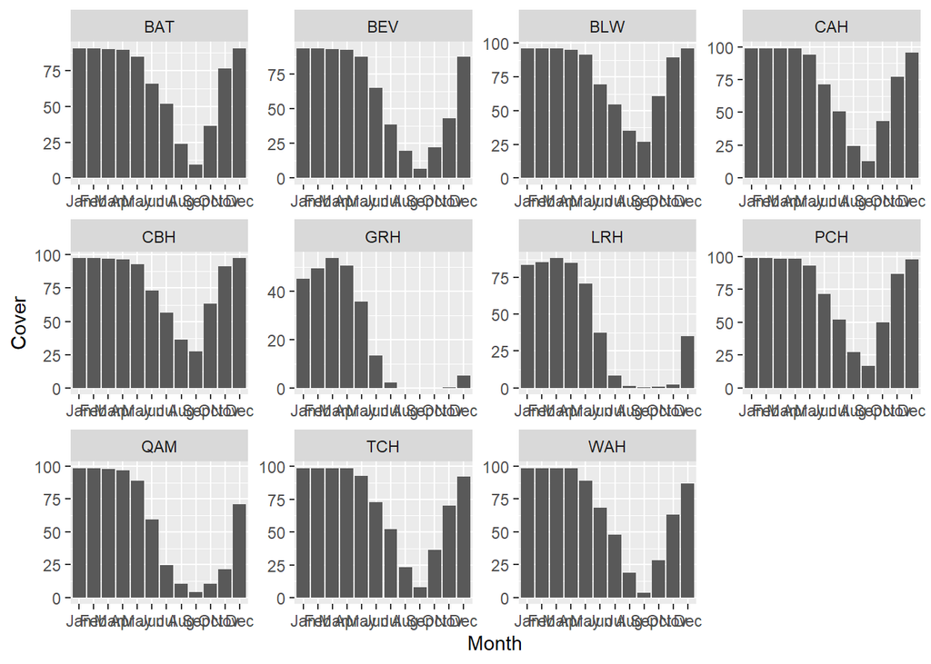

```r
# One nice feature of facet_wrap is that it allows for the ranges of the x- and y-axes to change between the panels (very useful when they vary considerably):
ggplot(data = seaice %>% filter(Year == 2010)) + aes(x = Month, y = Cover) + geom_col() + facet_wrap(~Herd, scales = "free")
```

### 9.6.10 Labels

We can change the labels of the graphs via xlab, ylab, and ggtitle:

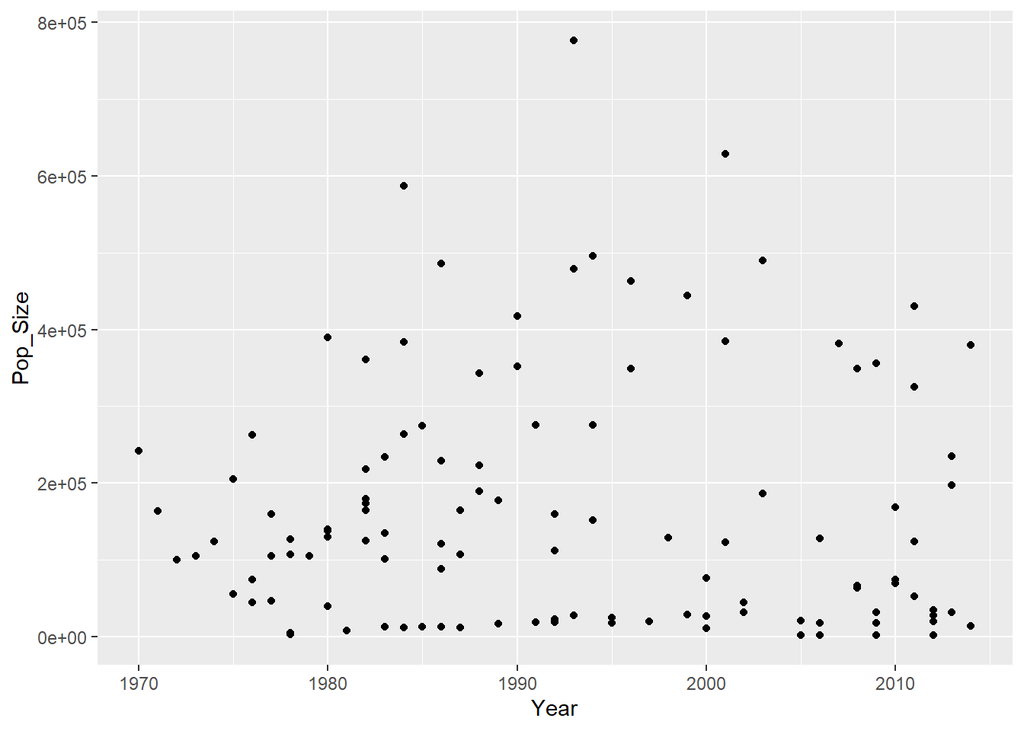

```r
pl <- ggplot(data = popsize) +
  aes(x = Year, y = Pop_Size) +
  geom_point()
pl + xlab("Year")
```

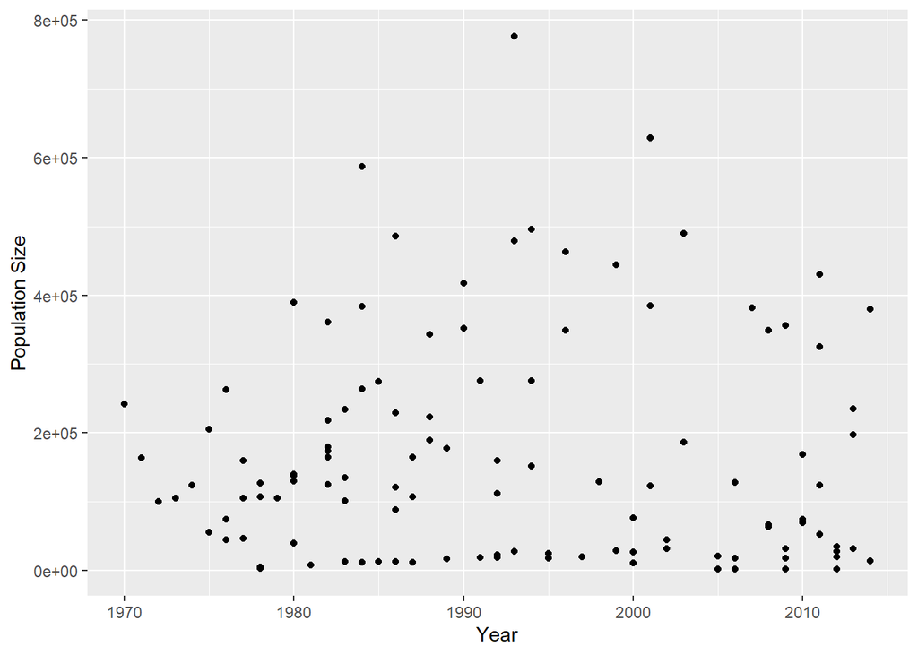

```r
pl + ylab("Population Size")
```

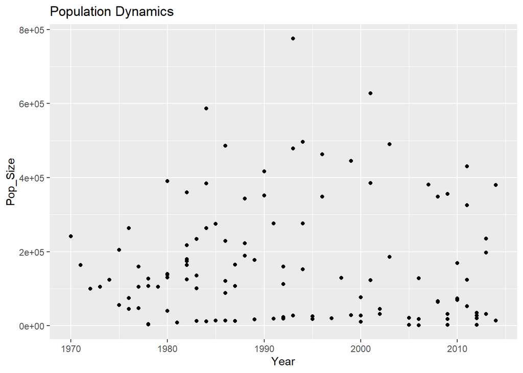

```r
pl + ggtitle("Population Dynamics")
```

### 9.6.11 Legends

By default, ggplot2 will place all the legends on the right of your plot. You can move them all to another position by specifying the legend.position option:

```r
pl <- ggplot(data = popsize) + aes(x = Herd, y = Pop_Size, fill = Herd) +
  geom_boxplot()
# default
show(pl)
```

[output not shown]

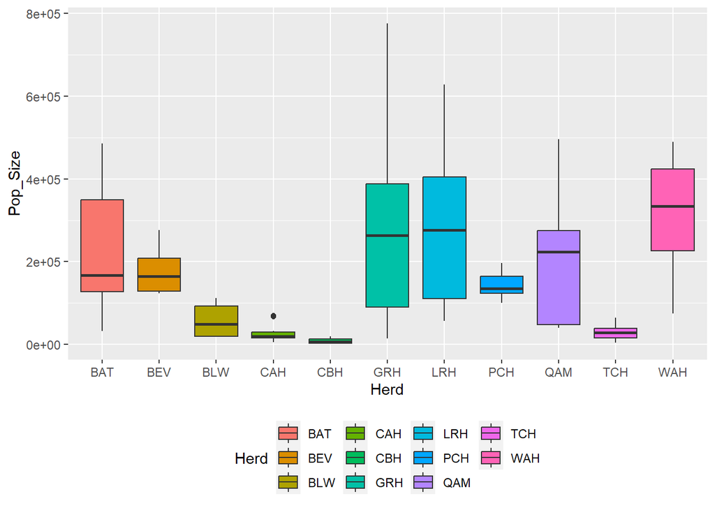

```r
# move legend
pl + theme(legend.position = "bottom")
```

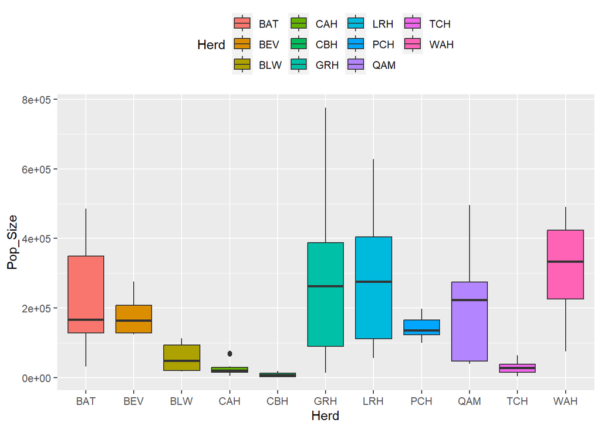

```r
pl + theme(legend.position = "top")
```

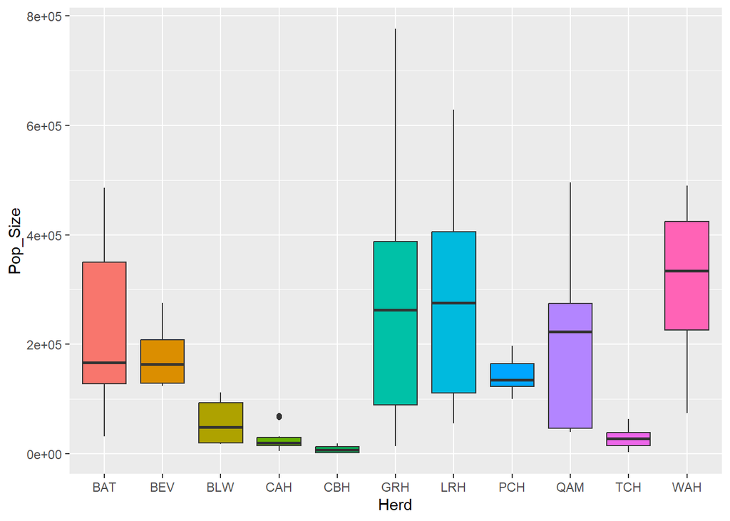

```r
# remove legend
pl + theme(legend.position = "none")
```

Each legend comes with a guide. You can use the command guide to change the title of a legend, alter its features, or to suppress it altogether. For example,

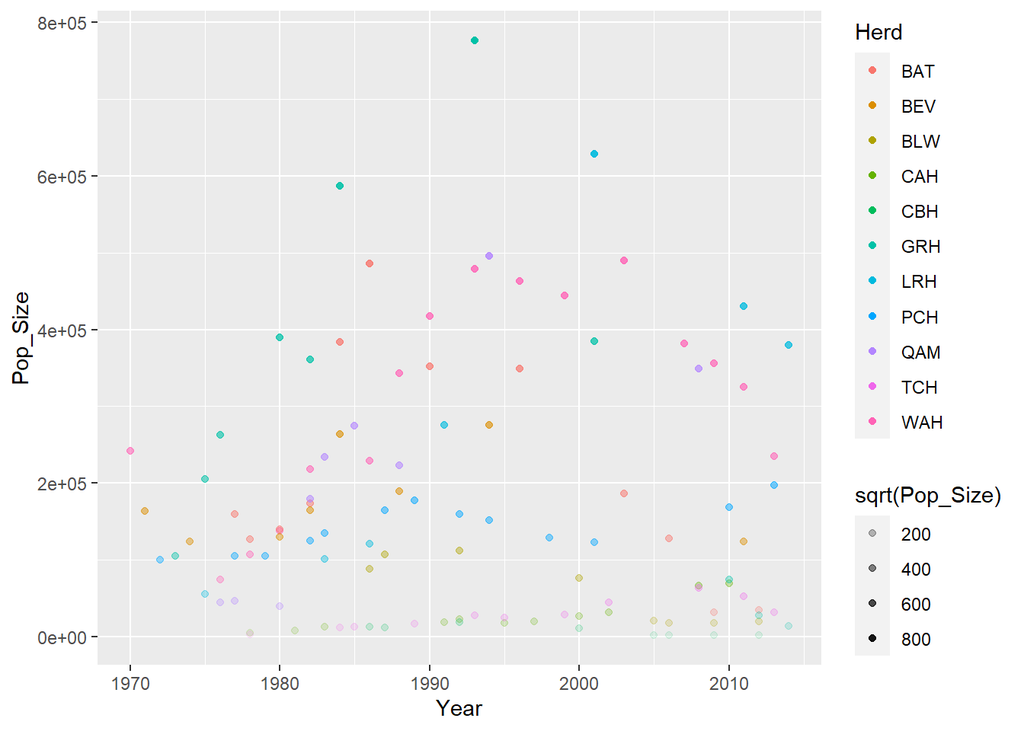

```r
pl <- ggplot(data = popsize) +
  aes(x = Year, y = Pop_Size, colour = Herd, alpha = sqrt(Pop_Size)) +
  geom_point()

show(pl)
```

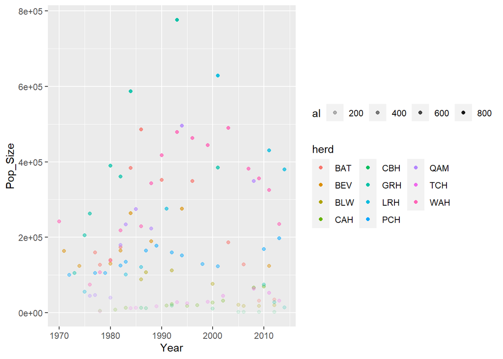

```r
pl + guides(colour = guide_legend(nrow = 4,title = "herd"), alpha = guide_legend(direction = "horizontal", title = "al"))
```

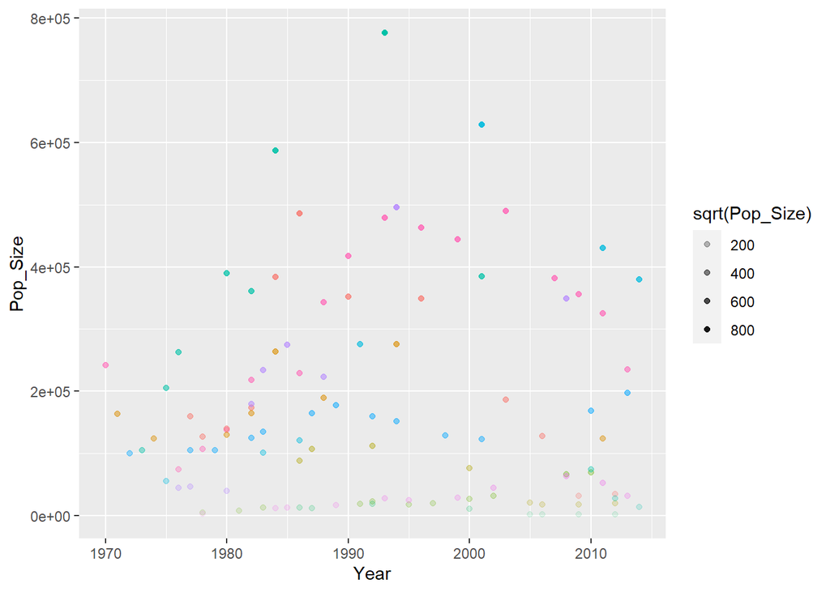

```r
# suppress only one legend
pl + guides(colour = "none")
```